# Regression

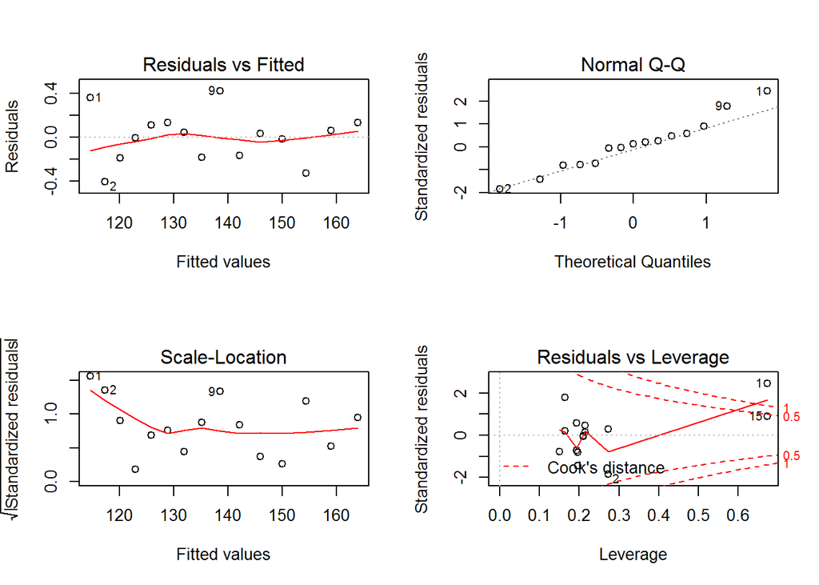

```r
par(mfrow = c(2, 2))
plot(fit3)
```

```r
state.x77
```

```
##                Population Income Illiteracy Life Exp Murder HS Grad Frost
## Alabama              3615   3624        2.1    69.05   15.1    41.3    20
## Alaska                365   6315        1.5    69.31   11.3    66.7   152
## Arizona              2212   4530        1.8    70.55    7.8    58.1    15
## Arkansas             2110   3378        1.9    70.66   10.1    39.9    65
## California          21198   5114        1.1    71.71   10.3    62.6    20
## Colorado             2541   4884        0.7    72.06    6.8    63.9   166
## Connecticut          3100   5348        1.1    72.48    3.1    56.0   139
## Delaware              579   4809        0.9    70.06    6.2    54.6   103
## Florida              8277   4815        1.3    70.66   10.7    52.6    11
## Georgia              4931   4091        2.0    68.54   13.9    40.6    60
## Hawaii                868   4963        1.9    73.60    6.2    61.9     0
## Idaho                 813   4119        0.6    71.87    5.3    59.5   126
## Illinois            11197   5107        0.9    70.14   10.3    52.6   127
## Indiana              5313   4458        0.7    70.88    7.1    52.9   122
## Iowa                 2861   4628        0.5    72.56    2.3    59.0   140
## Kansas               2280   4669        0.6    72.58    4.5    59.9   114
## Kentucky             3387   3712        1.6    70.10   10.6    38.5    95
## Louisiana            3806   3545        2.8    68.76   13.2    42.2    12
## Maine                1058   3694        0.7    70.39    2.7    54.7   161
## Maryland             4122   5299        0.9    70.22    8.5    52.3   101
## Massachusetts        5814   4755        1.1    71.83    3.3    58.5   103
## Michigan             9111   4751        0.9    70.63   11.1    52.8   125
## Minnesota            3921   4675        0.6    72.96    2.3    57.6   160
## Mississippi          2341   3098        2.4    68.09   12.5    41.0    50
## Missouri             4767   4254        0.8    70.69    9.3    48.8   108
## Montana               746   4347        0.6    70.56    5.0    59.2   155
## Nebraska             1544   4508        0.6    72.60    2.9    59.3   139
## Nevada                590   5149        0.5    69.03   11.5    65.2   188
## New Hampshire         812   4281        0.7    71.23    3.3    57.6   174
## New Jersey           7333   5237        1.1    70.93    5.2    52.5   115
## New Mexico           1144   3601        2.2    70.32    9.7    55.2   120
## New York            18076   4903        1.4    70.55   10.9    52.7    82
## North Carolina       5441   3875        1.8    69.21   11.1    38.5    80
## North Dakota          637   5087        0.8    72.78    1.4    50.3   186
## Ohio                10735   4561        0.8    70.82    7.4    53.2   124
## Oklahoma             2715   3983        1.1    71.42    6.4    51.6    82
## Oregon               2284   4660        0.6    72.13    4.2    60.0    44
## Pennsylvania        11860   4449        1.0    70.43    6.1    50.2   126
## Rhode Island          931   4558        1.3    71.90    2.4    46.4   127
```

[output cut: 47 more lines]

```
## Oklahoma        68782
## Oregon          96184
## Pennsylvania    44966
## Rhode Island     1049
## South Carolina  30225
## South Dakota    75955
## Tennessee       41328
## Texas          262134
## Utah            82096
## Vermont          9267
## Virginia        39780
## Washington      66570
## West Virginia   24070
## Wisconsin       54464
## Wyoming         97203
```

```r
states <- as.data.frame(state.x77[,c("Murder", "Population", "Illiteracy", "Income", "Frost")])
fit <- lm(Murder~., data = states) #lm(Murder~Illiteracy + Income + Frost, data = states)
summary(fit)
```

```
##
## Call:
## lm(formula = Murder ~ ., data = states)
##
## Residuals:
##     Min      1Q  Median      3Q     Max
## -4.7960 -1.6495 -0.0811  1.4815  7.6210
##
## Coefficients:
##              Estimate Std. Error t value Pr(>|t|)
## (Intercept) 1.235e+00  3.866e+00   0.319   0.7510
## Population  2.237e-04  9.052e-05   2.471   0.0173 *
## Illiteracy  4.143e+00  8.744e-01   4.738 2.19e-05 ***
## Income      6.442e-05  6.837e-04   0.094   0.9253
## Frost       5.813e-04  1.005e-02   0.058   0.9541
## ---
## Signif. codes:  0 '***' 0.001 '**' 0.01 '*' 0.05 '.' 0.1 ' ' 1
##
## Residual standard error: 2.535 on 45 degrees of freedom
## Multiple R-squared:  0.567,  Adjusted R-squared:  0.5285
## F-statistic: 14.73 on 4 and 45 DF,  p-value: 9.133e-08
```

# VIF(Variation Inflation Factor): 다중공선성 여부를 확인하는 통계

VIF루트값이 2보다 크면 다중공선성

```r
library(car)
sqrt(vif(fit))
```

```
## Population Illiteracy     Income      Frost
##   1.115922   1.471682   1.160096   1.443103
```

### outlier 확인

outlier : 표준 잔차 2배 이상 크거나 -2배이상 작은 값들을 의미 High leverage points(큰 지레점) + 평균 hat통계량 이용 + p/n (p는 절편을 포함한 인수들의 갯수) + 해당 값보다 2-3배 이상인 값은 outlier로 처리 영향 관측치(Influential Observation) + cook’s distance, D statistics + cook’s D > 4/n-k-1 (n:샘플 수, k: 예측인자의 수)

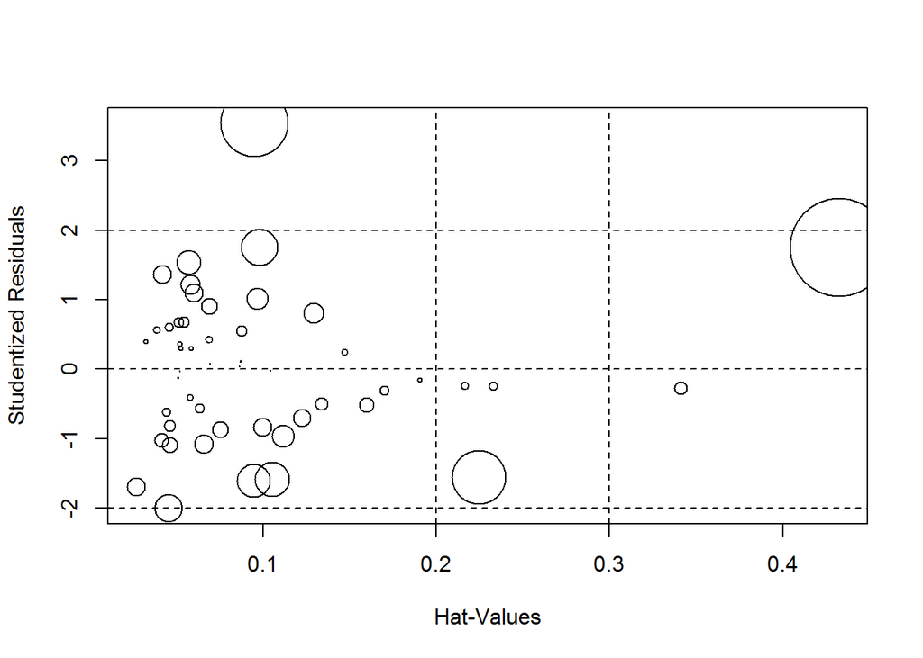

```r
influencePlot(fit, id = list(method = "identify"))
```

y축은 표준 잔차이므로 2보다 큰 데이터는 outlier 큰 지레점 : 5/50 = 0.1 영향 관측치: 원의 크기(원의 크면 outlier일 가능성이 있음)

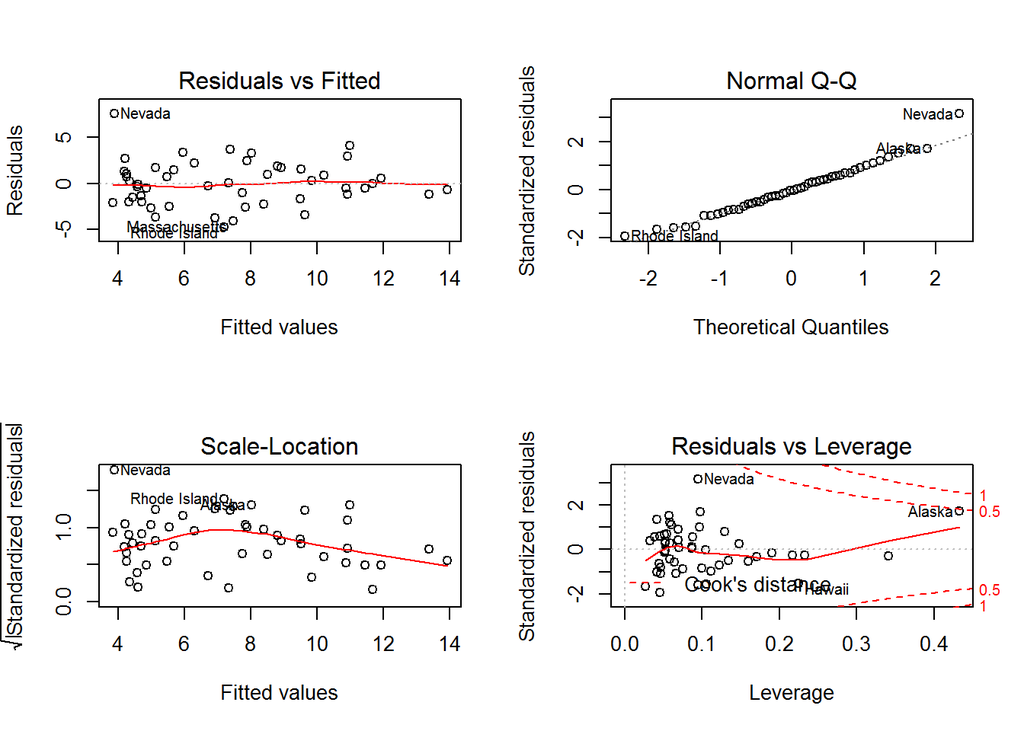

```r
par(mfrow = c(2,2))
plot(fit)
```

예측모델 적용 조건(선형, 독립, 정규, 등분산)에 적합하지 않을 시 교정 1. 정규성을 만족하지 않을 경우 + 종속변수의 변환을 시도(Y값에 람다제곱을 씌워서 변환) 후, 이것을 그래프 가운데로 transformation 한다. + -2, -1, -0.5, 0, 1, 2 (2: y^2, 0.5: sqrt(y), 0: log(y), -1: 1/y, -2: 1/y^2)

```r
summary(powerTransform(states$Murder))
```

```
## bcPower Transformation to Normality
##               Est Power Rounded Pwr Wald Lwr Bnd Wald Upr Bnd
## states$Murder    0.6055           1       0.0884       1.1227
##
## Likelihood ratio test that transformation parameter is equal to 0
##  (log transformation)
##                            LRT df     pval
## LR test, lambda = (0) 5.665991  1 0.017297
##
## Likelihood ratio test that no transformation is needed
##                            LRT df    pval
## LR test, lambda = (1) 2.122763  1 0.14512
```

선형을 만족하지 않을 때

```r
boxTidwell(Murder~Population + Illiteracy, data = states)
```

```
##            MLE of lambda Score Statistic (z) Pr(>|z|)
## Population       0.86939             -0.3228   0.7468
## Illiteracy       1.35812              0.6194   0.5357
##
## iterations =  19
```

등분산성을 만족하지 않는 경우

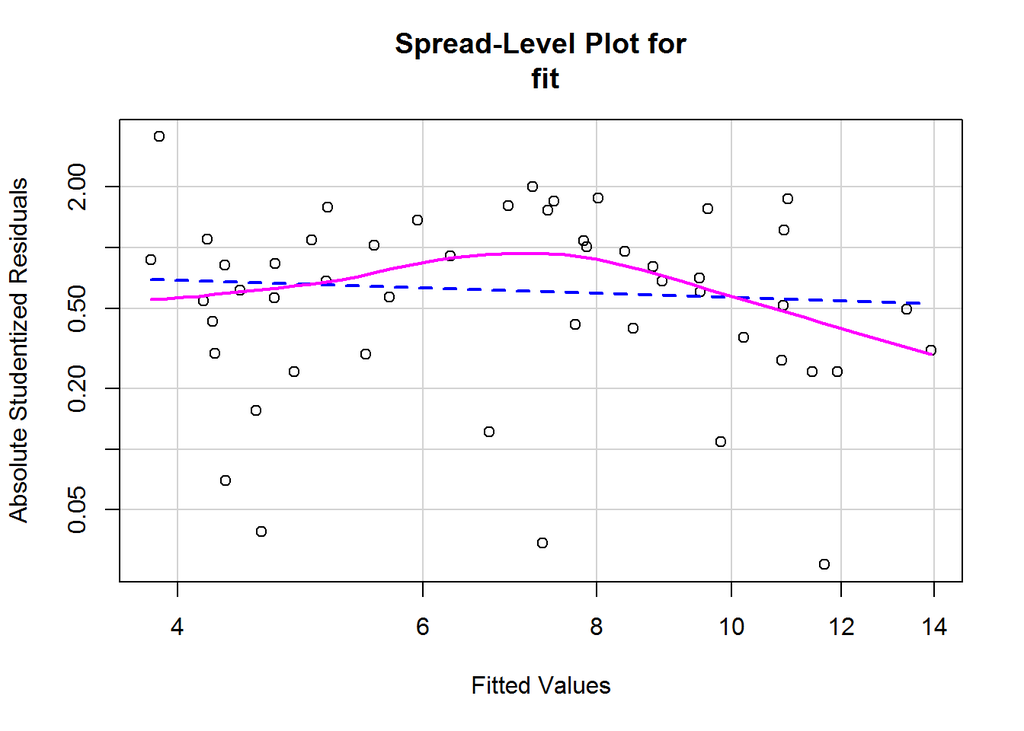

```
##
## Suggested power transformation:  1.209626
```

```r
spreadLevelPlot(fit)
```

### 회귀모형 고르기

```r
fit1 <- lm(Murder ~ ., data = states)
summary(fit1)
```

```
##
## Call:
## lm(formula = Murder ~ ., data = states)
##
## Residuals:
##     Min      1Q  Median      3Q     Max
## -4.7960 -1.6495 -0.0811  1.4815  7.6210
##
## Coefficients:
##              Estimate Std. Error t value Pr(>|t|)
## (Intercept) 1.235e+00  3.866e+00   0.319   0.7510
## Population  2.237e-04  9.052e-05   2.471   0.0173 *
## Illiteracy  4.143e+00  8.744e-01   4.738 2.19e-05 ***
## Income      6.442e-05  6.837e-04   0.094   0.9253
## Frost       5.813e-04  1.005e-02   0.058   0.9541
## ---
## Signif. codes:  0 '***' 0.001 '**' 0.01 '*' 0.05 '.' 0.1 ' ' 1
##
## Residual standard error: 2.535 on 45 degrees of freedom
## Multiple R-squared:  0.567,  Adjusted R-squared:  0.5285
## F-statistic: 14.73 on 4 and 45 DF,  p-value: 9.133e-08
```

Income과 Frost의 p값이 각각 0.925, 0.954로 유의하지 않다. 두 변수를 제외하고 다시 회귀모형을 만듬

```r
fit2 <- lm(Murder ~ Population + Illiteracy, data = states)
summary(fit2)
```

```
##
## Call:
## lm(formula = Murder ~ Population + Illiteracy, data = states)
##
## Residuals:
##     Min      1Q  Median      3Q     Max
## -4.7652 -1.6561 -0.0898  1.4570  7.6758
##
## Coefficients:
##              Estimate Std. Error t value Pr(>|t|)
## (Intercept) 1.652e+00  8.101e-01   2.039  0.04713 *
## Population  2.242e-04  7.984e-05   2.808  0.00724 **
## Illiteracy  4.081e+00  5.848e-01   6.978 8.83e-09 ***
## ---
## Signif. codes:  0 '***' 0.001 '**' 0.01 '*' 0.05 '.' 0.1 ' ' 1
##
## Residual standard error: 2.481 on 47 degrees of freedom
## Multiple R-squared:  0.5668, Adjusted R-squared:  0.5484
## F-statistic: 30.75 on 2 and 47 DF,  p-value: 2.893e-09
```

다중회귀이므로 Adjusted R-squared값을 확인 ### AIC로 모형 비교 AIC(Akaike’s An Information Criterion)

```r
AIC(fit1, fit2)
```

```
##      df      AIC
## fit1  6 241.6429
## fit2  4 237.6565
```

AIC값이 작은 fit2가 더 좋은 모델이다.

### stepwise regression

- forward stepwise regression

```r
min.model <- lm(Murder ~ 1, data = states)
fwd.model <- step(min.model, direction = "forward",
                  scope = (Murder~Population+Illiteracy+Income+Frost))
```

```
## Start:  AIC=131.59
## Murder ~ 1
##
##              Df Sum of Sq    RSS     AIC
## + Illiteracy  1    329.98 337.76  99.516
## + Frost       1    193.91 473.84 116.442
## + Population  1     78.85 588.89 127.311
## + Income      1     35.35 632.40 130.875
## <none>                    667.75 131.594
##
## Step:  AIC=99.52
## Murder ~ Illiteracy
##
##              Df Sum of Sq    RSS     AIC
## + Population  1    48.517 289.25  93.763
## <none>                    337.76  99.516
## + Frost       1     5.387 332.38 100.712
## + Income      1     4.916 332.85 100.783
##
## Step:  AIC=93.76
## Murder ~ Illiteracy + Population
##
##          Df Sum of Sq    RSS    AIC
## <none>                289.25 93.763
## + Income  1  0.057022 289.19 95.753
## + Frost   1  0.021447 289.22 95.759
```

- backward stepwise regression

```r
full.model <- lm(Murder~., data = states)
reduced.model <- step(full.model, direction = "backward", trace = 0)
summary(reduced.model)
```

```
##
## Call:
## lm(formula = Murder ~ Population + Illiteracy, data = states)
##
## Residuals:
##     Min      1Q  Median      3Q     Max
## -4.7652 -1.6561 -0.0898  1.4570  7.6758
##
## Coefficients:
##              Estimate Std. Error t value Pr(>|t|)
## (Intercept) 1.652e+00  8.101e-01   2.039  0.04713 *
## Population  2.242e-04  7.984e-05   2.808  0.00724 **
## Illiteracy  4.081e+00  5.848e-01   6.978 8.83e-09 ***
## ---
## Signif. codes:  0 '***' 0.001 '**' 0.01 '*' 0.05 '.' 0.1 ' ' 1
##
## Residual standard error: 2.481 on 47 degrees of freedom
## Multiple R-squared:  0.5668, Adjusted R-squared:  0.5484
## F-statistic: 30.75 on 2 and 47 DF,  p-value: 2.893e-09
```

ALL Subset Regression install.packages(“leaps”)

```r
library(leaps)
```

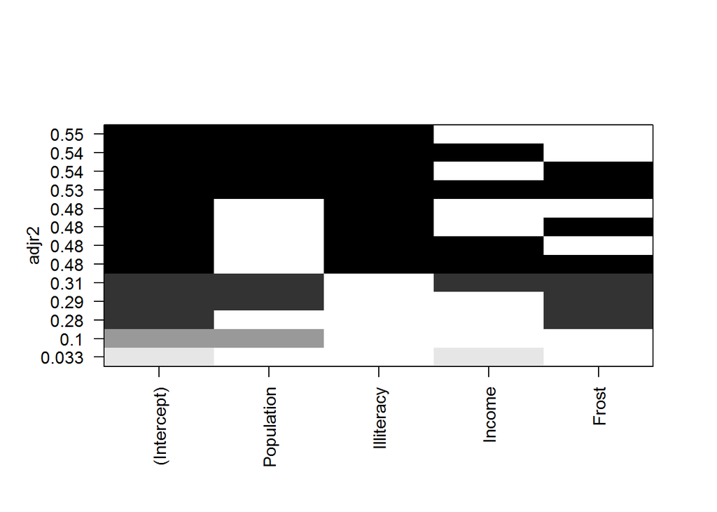

```r
leaps <- regsubsets(Murder~Population + Illiteracy + Income + Frost, data = states, nbest = 4)
plot(leaps, scale = "adjr2")
```